# Optimizing a Sparse PK Design in Pediatric Patients

Lucie Fayette, Romain Leroux

# Introduction

This example is taken from Tim Waterhouse’s webinar *A Gentle Introduction to Optimal Design for Pharmacometric Models* (optimal-design-2023). It shows how PFIM evaluates and optimizes a sparse pharmacokinetic sampling design in pediatric patients.

A population pharmacokinetic model for orally administered Mockdrozaline was developed in adults. The objective here is to assess and improve a sparse pediatric design so that population parameters can be estimated with adequate precision.

The adult model consists of:

- a one-compartment disposition model with first-order absorption,
- allometric scaling of clearance and volume with body weight (reference 70 kg),
- log-normal inter-individual variability on `Cl`, `V`, and `ka`,
- combined proportional and additive residual error.

# Population model

## Structural model

Clearance and volume enter the oral absorption formula after scaling with `(WT/70)^beta`, where `WT` is body weight in kg and the exponents are fixed at the adult estimates.

```r
modelEquations = list(
  RespPK = paste(
    "dose_RespPK/(V*(WT/70)^(beta_V_WT)) *",
    "ka/(ka - (Cl*(WT/70)^(beta_Cl_WT))/(V*(WT/70)^(beta_V_WT))) *",
    "(exp(-(Cl*(WT/70)^(beta_Cl_WT))/(V*(WT/70)^(beta_V_WT)) * t)",
    "- exp(-ka * t))"
  )
)
```

## Population parameters

Typical values `V`, `Cl`, and `ka` refer to a 70 kg adult. Weight exponents `beta_V_WT` and `beta_Cl_WT` are included in the equations but fixed (`fixedMu = TRUE`) because they are not re-estimated in the pediatric study.

```r
modelParameters = list(
  ModelParameter(name = "V",  distribution = LogNormal(mu = 100,  omega = sqrt(0.1))),
  ModelParameter(name = "Cl", distribution = LogNormal(mu = 10,   omega = sqrt(0.08))),
  ModelParameter(name = "ka", distribution = LogNormal(mu = 0.25, omega = sqrt(0.2))),
  ModelParameter(
    name = "beta_V_WT", distribution = Normal(mu = 1, omega = 0),
    fixedMu = TRUE, fixedOmega = TRUE
  ),
  ModelParameter(
    name = "beta_Cl_WT", distribution = Normal(mu = 0.75, omega = 0),
    fixedMu = TRUE, fixedOmega = TRUE
  )
)
```

## Residual error

Concentrations are modelled with combined proportional and additive residual error (PopED: `feps.add.prop`). Writing $f$ for the prediction (`RespPK`), both tools use the same variance formula; they differ in what the numbers mean:

$$\mathrm{Var}(y \mid f) = \sigma_{\mathrm{add}}^2 +
(\sigma_{\mathrm{prop}}\, f)^2 .$$

|  | Proportional term | Additive term |
| --- | --- | --- |
| PopED / NONMEM (`sigma`, `SIGMA`) | variance 0.05 | variance 1 |
| PFIM `Combined2` | SD `sigmaSlope = sqrt(0.05)` | SD `sigmaInter = 1` |

Tim’s tables sometimes write `sigma_prop = 0.05`, which looks like “5% error”. In `optimal-design-2023`, that value is still a variance in `sigma`, not a proportional SD. Copying `0.05` into `sigmaSlope` in PFIM would not reproduce PopED (it would use variance $0.05^2$ instead of $0.05$). Inter-individual variability follows the same variance → SD rule via `omega = sqrt(d)` in the chunk above. Details and a short checklist are in `vignette("Vignette_05_gcse_pkpd", package = "PFIM")`, section *PFIM, PopED, and cross-tool equivalence*.

```r
errorModelRespPK = Combined2(
  output = "RespPK",
  sigmaInter = 1,
  sigmaSlope = sqrt(0.05)
)
modelError = list(errorModelRespPK)
```

## Reference body weight

PFIM reads `WT` as a free symbol in the equation (not as a `Covariate()` object). For this homogeneous pediatric cohort, all subjects share the same weight.

```r
WT = 32
```

# Study design

Mockdrozaline is administered as 10 mg once daily for 24 weeks (`n = 12` subjects). Doses are expressed in the same units as in the Tim Waterhouse material (`mg × 1000` in the administration record).

```r
week_h = 24 * 7
lastDose = week_h * 24
dose_times = seq(0, lastDose, by = 24)

administrationRespPK = Administration(
  outcome = "RespPK",
  timeDose = dose_times,
  dose = rep(10 * 1000, times = length(dose_times))
)
```

The initial sparse design includes five samples:

- 5 h after the first dose,
- predose at weeks 8, 12, and 24,
- 168 h after the last dose.

```r
observation_times = c(
  5,
  week_h * 8 - 1,
  week_h * c(12, 24),
  lastDose + 168
)

samplingTimesRespPK = SamplingTimes(
  outcome = "RespPK",
  samplings = observation_times
)

armInitial = Arm(
  name = "Initial arm",
  size = 12,
  administrations = list(administrationRespPK),
  samplingTimes = list(samplingTimesRespPK)
)

designInitial = Design(
  name = "designInitial",
  arms = list(armInitial)
)
```

# Evaluation of the initial design

The population Fisher information matrix (FIM) is computed for the initial design.

Evaluation and PSO runs are computed by `vignette_04_tim_waterhouse_pediatric_execute.R` (run once, then cached as `.RDS` in `data/`).

```r
evaluationPopFimInitial = Evaluation(
  name = "FIM design initial",
  modelParameters = modelParameters,
  modelEquations = modelEquations,
  modelError = modelError,
  designs = list(designInitial),
  outputs = list("RespPK"),
  fimType = "population"
)

evaluationPopFimInitial = run(evaluationPopFimInitial)
```

## Predicted concentration-time profile

```
#> $designInitial
#> $designInitial$`Initial arm`
#> $designInitial$`Initial arm`$RespPK
```

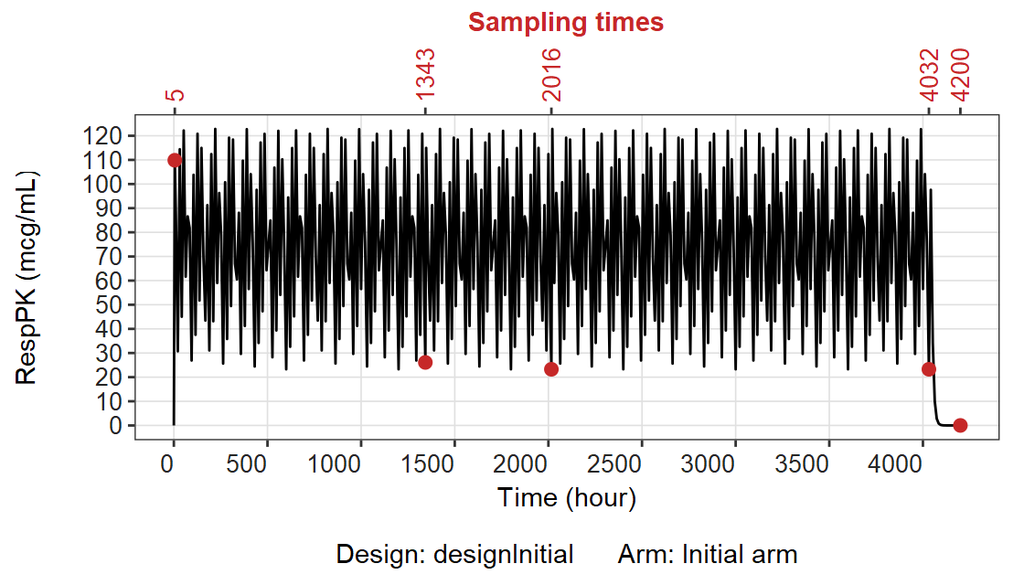

```r
plotEvaluation(evaluationPopFimInitial, plotOptions)
```

## Design summary

```r
show(evaluationPopFimInitial)
```

```r
show(evaluationPopFimInitial)
```

```
#>
#>   Population Fisher Matrix
#>
#>                         μ_V        μ_Cl       μ_ka         ω²_V      ω²_Cl       ω²_ka σ_inter_RespPK σ_slope_RespPK
#> μ_V             0.005191013 -0.02212943  -1.264968   0.00000000   0.000000  0.00000000     0.00000000        0.00000
#> μ_Cl           -0.022129430  1.24867057   2.833570   0.00000000   0.000000  0.00000000     0.00000000        0.00000
#> μ_ka           -1.264968309  2.83356962 317.133094   0.00000000   0.000000  0.00000000     0.00000000        0.00000
#> ω²_V            0.000000000  0.00000000   0.000000 112.27754970  20.404653 41.67043806     0.03434818       42.42871
#> ω²_Cl           0.000000000  0.00000000   0.000000  20.40465277 649.657584  2.09091583     0.12799100       71.00212
#> ω²_ka           0.000000000  0.00000000   0.000000  41.67043806   2.090916 16.36936838     0.01137853       20.54078
#> σ_inter_RespPK  0.000000000  0.00000000   0.000000   0.03434818   0.127991  0.01137853    24.05314802        6.90698
#> σ_slope_RespPK  0.000000000  0.00000000   0.000000  42.42871155  71.002117 20.54078137     6.90697983      965.24067
#>
#>   Fixed effects (μ)
#>
#>               μ_V        μ_Cl       μ_ka
#> μ_V   0.005191013 -0.02212943  -1.264968
#> μ_Cl -0.022129430  1.24867057   2.833570
#> μ_ka -1.264968309  2.83356962 317.133094
#>
#>   Variance components (ω², γ², σ)
#>
#>                        ω²_V      ω²_Cl       ω²_ka σ_inter_RespPK σ_slope_RespPK
#> ω²_V           112.27754970  20.404653 41.67043806     0.03434818       42.42871
#> ω²_Cl           20.40465277 649.657584  2.09091583     0.12799100       71.00212
#> ω²_ka           41.67043806   2.090916 16.36936838     0.01137853       20.54078
#> σ_inter_RespPK   0.03434818   0.127991  0.01137853    24.05314802        6.90698
#> σ_slope_RespPK  42.42871155  71.002117 20.54078137     6.90697983      965.24067
#>
#>   Determinant, condition numbers and D-criterion
#>
#> Determinant: 26095079
#> D-criterion: 8.454148
#> Condition number (fixed effects): 6403571
#> Condition number (variance components): 1353.512
#>
#>   Parameters estimation
#>
#> Parameter               Value           SE     RSE(%)
#> μ_V              100.0000000 142.08529815  142.08530
#> μ_Cl              10.0000000   1.54877798   15.48778
#> μ_ka               0.2500000   0.55839813  223.35925
#> ω²_V              0.1000000   0.41853695  418.53695
#> ω²_Cl             0.0800000   0.04070788   50.88485
#> ω²_ka             0.2000000   1.09951923  549.75962
#> σ_inter_RespPK      1.0000000   0.20411978   20.41198
#> σ_slope_RespPK      0.2236068   0.03318821   14.84222
```

## D-criterion

```r
getDcriterion(evaluationPopFimInitial)
```

```r
getDcriterion(evaluationPopFimInitial)
```

```
#> [1] 8.454148
```

Designs can be compared with the D-criterion; relative standard errors (RSE) are often easier to interpret.

## Relative standard errors

```r
getRSE(evaluationPopFimInitial)
```

```r
getRSE(evaluationPopFimInitial)
```

```
#>                parametersValues       RSE
#> μ_V                 100.0000000 142.08530
#> μ_Cl                 10.0000000  15.48778
#> μ_ka                  0.2500000 223.35925
#> ω²_V                  0.1000000 418.53695
#> ω²_Cl                 0.0800000  50.88485
#> ω²_ka                 0.2000000 549.75962
#> σ_inter_RespPK        1.0000000  20.41198
#> σ_slope_RespPK        0.2236068  14.84222
```

# D-optimal sampling-time optimization

Sampling times can be optimized within protocol windows. Particle-swarm settings below use a small iteration count so the vignette renders in reasonable time; increase `maxIteration` for production work.

## Five samples

One window covers absorption (0–6 h after the first dose), three windows capture steady-state troughs (weeks 8, 12, and 24), and one window covers 96–168 h after the last dose.

```r
samplingConstraintsRespPK5 = SamplingTimeConstraints(
  outcome = "RespPK",
  initialSamplings = observation_times,
  samplingsWindows = list(
    c(0, 6),
    c(week_h * 8 - 1, week_h * 8),
    c(week_h * 12 - 1, week_h * 12),
    c(week_h * 24 - 1, week_h * 24),
    c(lastDose + 96, lastDose + 168)
  ),
  numberOfTimesByWindows = c(1, 1, 1, 1, 1),
  minSampling = c(1, 1, 1, 1, 1)
)
```

```r
armOptim5 = Arm(
  name = "ArmOptim5",
  size = 12,
  administrations = list(administrationRespPK),
  samplingTimes = list(samplingTimesRespPK),
  samplingTimesConstraints = list(samplingConstraintsRespPK5)
)

designOptim5 = Design(
  name = "designOptim5",
  arms = list(armOptim5)
)

optimizationPopFIM5 = Optimization(
  name = "Optimization 5 samples",
  modelEquations = modelEquations,
  modelParameters = modelParameters,
  modelError = modelError,
  optimizer = "PSOAlgorithm",
  optimizerParameters = list(
    maxIteration = 10,
    populationSize = 50,
    personalLearningCoefficient = 2.05,
    globalLearningCoefficient = 2.05,
    seed = 1234,
    showProcess = FALSE
  ),
  designs = list(designOptim5),
  fimType = "population",
  outputs = list("RespPK")
)

optimizationPopFIM5 = run(optimizationPopFIM5)
```

```r
show(optimizationPopFIM5)
```

```r
show(optimizationPopFIM5)
```

```
#>
#> --- Optimal design ---
#>
#>   Arms name Number of subjects Outcome
#> 1 ArmOptim5                 12  RespPK
#>                                                                                                                                                                                                                                                                                                          …
#> 1 10000, 10000, 10000, 10000, 10000, 10000, 10000, 10000, 10000, 10000, 10000, 10000, 10000, 10000, 10000, 10000, 10000, 10000, 10000, 10000, 10000, 10000, 10000, 10000, 10000, 10000, 10000, 10000, 10000, 10000, 10000, 10000, 10000, 10000, 10000, 10000, 10000, 10000, 10000, 10000, 10000, 10000, 1…
#>                   Sampling times
#> 1 (0.33, 1344, 2015, 4032, 4128)
#>
#>   Population Fisher Matrix
#>
#>                         μ_V        μ_Cl       μ_ka       ω²_V       ω²_Cl      ω²_ka σ_inter_RespPK σ_slope_RespPK
#> μ_V             0.004149819 -0.02856067  -1.327250  0.0000000   0.0000000  0.0000000      0.0000000       0.000000
#> μ_Cl           -0.028560666  1.27045005  -1.208882  0.0000000   0.0000000  0.0000000      0.0000000       0.000000
#> μ_ka           -1.327250132 -1.20888211 530.944022  0.0000000   0.0000000  0.0000000      0.0000000       0.000000
#> ω²_V            0.000000000  0.00000000   0.000000 71.7541623  33.9879857 45.8748155      0.2105445      14.081909
#> ω²_Cl           0.000000000  0.00000000   0.000000 33.9879857 672.5180543  0.3805719      0.6717039      52.863270
#> ω²_ka           0.000000000  0.00000000   0.000000 45.8748155   0.3805719 45.8824145      0.3673430      23.379602
#> σ_inter_RespPK  0.000000000  0.00000000   0.000000  0.2105445   0.6717039  0.3673430     24.0563894       7.222854
#> σ_slope_RespPK  0.000000000  0.00000000   0.000000 14.0819091  52.8632704 23.3796024      7.2228537     918.086053
#>
#>   Fixed effects (μ)
#>
#>               μ_V        μ_Cl       μ_ka
#> μ_V   0.004149819 -0.02856067  -1.327250
#> μ_Cl -0.028560666  1.27045005  -1.208882
#> μ_ka -1.327250132 -1.20888211 530.944022
#>
#>   Variance components (ω², γ², σ)
#>
#>                      ω²_V       ω²_Cl      ω²_ka σ_inter_RespPK σ_slope_RespPK
#> ω²_V           71.7541623  33.9879857 45.8748155      0.2105445      14.081909
#> ω²_Cl          33.9879857 672.5180543  0.3805719      0.6717039      52.863270
#> ω²_ka          45.8748155   0.3805719 45.8824145      0.3673430      23.379602
#> σ_inter_RespPK  0.2105445   0.6717039  0.3673430     24.0563894       7.222854
#> σ_slope_RespPK 14.0819091  52.8632704 23.3796024      7.2228537     918.086053
#>
#>   Determinant, condition numbers and D-criterion
#>
#> Determinant: 488075482
#> D-criterion: 12.1916
#> Condition number (fixed effects): 11769929
#> Condition number (variance components): 89.6053
#>
#>   Parameters estimation
#>
#> Parameter               Value           SE     RSE(%)
#> μ_V              100.0000000 148.84145795  148.84146
#> μ_Cl              10.0000000   3.81302408   38.13024
#> μ_ka               0.2500000   0.38298792  153.19517
#> ω²_V              0.1000000   0.20391433  203.91433
#> ω²_Cl             0.0800000   0.04002444   50.03055
#> ω²_ka             0.2000000   0.25333384  126.66692
#> σ_inter_RespPK      1.0000000   0.20413127   20.41313
#> σ_slope_RespPK      0.2236068   0.03344128   14.95539
```

The optimized five-sample design improves the D-criterion, but precision on the typical parameters remains limited.

## Six samples

A sixth occasion is added in the washout phase (72 h and 168 h after the last dose), as in the extended Tim Waterhouse scenario.

```r
observation_times_6 = c(
  5,
  week_h * 8 - 1,
  week_h * c(12, 24),
  lastDose + 72,
  lastDose + 168
)

samplingConstraintsRespPK6 = SamplingTimeConstraints(
  outcome = "RespPK",
  initialSamplings = observation_times_6,
  samplingsWindows = list(
    c(0, 6),
    c(week_h * 8 - 1, week_h * 8),
    c(week_h * 12 - 1, week_h * 12),
    c(week_h * 24 - 1, week_h * 24),
    c(lastDose, lastDose + 168),
    c(lastDose + 167.5, lastDose + 168)
  ),
  numberOfTimesByWindows = c(1, 1, 1, 1, 1, 1),
  minSampling = c(1, 1, 1, 1, 1, 1)
)
```

```r
armOptim6 = Arm(
  name = "ArmOptim6",
  size = 12,
  administrations = list(administrationRespPK),
  samplingTimes = list(
    SamplingTimes(outcome = "RespPK", samplings = observation_times_6)
  ),
  samplingTimesConstraints = list(samplingConstraintsRespPK6)
)

designOptim6 = Design(
  name = "designOptim6",
  arms = list(armOptim6)
)

optimizationPopFIM6 = Optimization(
  name = "Optimization 6 samples",
  modelEquations = modelEquations,
  modelParameters = modelParameters,
  modelError = modelError,
  optimizer = "PSOAlgorithm",
  optimizerParameters = list(
    maxIteration = 10,
    populationSize = 50,
    personalLearningCoefficient = 2.05,
    globalLearningCoefficient = 2.05,
    seed = 1234,
    showProcess = FALSE
  ),
  designs = list(designOptim6),
  fimType = "population",
  outputs = list("RespPK")
)

optimizationPopFIM6 = run(optimizationPopFIM6)
```

```r
show(optimizationPopFIM6)
```

```r
show(optimizationPopFIM6)
```

```
#>
#> --- Optimal design ---
#>
#>   Arms name Number of subjects Outcome
#> 1 ArmOptim6                 12  RespPK
#>                                                                                                                                                                                                                                                                                                          …
#> 1 10000, 10000, 10000, 10000, 10000, 10000, 10000, 10000, 10000, 10000, 10000, 10000, 10000, 10000, 10000, 10000, 10000, 10000, 10000, 10000, 10000, 10000, 10000, 10000, 10000, 10000, 10000, 10000, 10000, 10000, 10000, 10000, 10000, 10000, 10000, 10000, 10000, 10000, 10000, 10000, 10000, 10000, 1…
#>                                        Sampling times
#> 1 (0.47, 1343.25, 2015.23, 4031.04, 4072.97, 4199.68)
#>
#>   Population Fisher Matrix
#>
#>                         μ_V        μ_Cl        μ_ka       ω²_V        ω²_Cl       ω²_ka σ_inter_RespPK σ_slope_RespPK
#> μ_V             0.006737006 -0.02518152  -0.8183397   0.000000   0.00000000  0.00000000      0.0000000        0.00000
#> μ_Cl           -0.025181524  1.27906374  -0.6138614   0.000000   0.00000000  0.00000000      0.0000000        0.00000
#> μ_ka           -0.818339690 -0.61386140 631.9699997   0.000000   0.00000000  0.00000000      0.0000000        0.00000
#> ω²_V            0.000000000  0.00000000   0.0000000 189.113534  26.42121406 17.43957937      8.5638376       43.73878
#> ω²_Cl           0.000000000  0.00000000   0.0000000  26.421214 681.66835435  0.09813172      0.4955298       58.22905
#> ω²_ka           0.000000000  0.00000000   0.0000000  17.439579   0.09813172 65.00424488      2.3414104       34.21810
#> σ_inter_RespPK  0.000000000  0.00000000   0.0000000   8.563838   0.49552976  2.34141042     26.5972921       18.50211
#> σ_slope_RespPK  0.000000000  0.00000000   0.0000000  43.738779  58.22905274 34.21809952     18.5021058      991.23066
#>
#>   Fixed effects (μ)
#>
#>               μ_V        μ_Cl        μ_ka
#> μ_V   0.006737006 -0.02518152  -0.8183397
#> μ_Cl -0.025181524  1.27906374  -0.6138614
#> μ_ka -0.818339690 -0.61386140 631.9699997
#>
#>   Variance components (ω², γ², σ)
#>
#>                      ω²_V        ω²_Cl       ω²_ka σ_inter_RespPK σ_slope_RespPK
#> ω²_V           189.113534  26.42121406 17.43957937      8.5638376       43.73878
#> ω²_Cl           26.421214 681.66835435  0.09813172      0.4955298       58.22905
#> ω²_ka           17.439579   0.09813172 65.00424488      2.3414104       34.21810
#> σ_inter_RespPK   8.563838   0.49552976  2.34141042     26.5972921       18.50211
#> σ_slope_RespPK  43.738779  58.22905274 34.21809952     18.5021058      991.23066
#>
#>   Determinant, condition numbers and D-criterion
#>
#> Determinant: 8.4334e+11
#> D-criterion: 30.95639
#> Condition number (fixed effects): 122775.1
#> Condition number (variance components): 38.93445
#>
#>   Parameters estimation
#>
#> Parameter               Value           SE     RSE(%)
#> μ_V              100.0000000  13.93528758  13.935288
#> μ_Cl              10.0000000   0.92863143   9.286314
#> μ_ka               0.2500000   0.04380307  17.521230
#> ω²_V              0.1000000   0.07447811  74.478111
#> ω²_Cl             0.0800000   0.03849369  48.117107
#> ω²_ka             0.2000000   0.12658928  63.294638
#> σ_inter_RespPK      1.0000000   0.19645472  19.645472
#> σ_slope_RespPK      0.2236068   0.03239345  14.486792
```

```r
optArms = prop(optimizationPopFIM6, "optimisationAlgorithmOutputs")$optimalArms
optSamplings = prop(prop(optArms[[1]], "samplingTimes")[[1]], "samplings")
optSamplings
```

```r
optSamplings
```

```
#> [1]    0.465695 1343.251373 2015.229624 4031.036903 4072.970080 4199.678279
```

With these settings, the typical values `V`, `Cl`, and `ka` are expected to reach RSE below 20% after optimization (variance components are usually less precisely estimated).

# Discussion

Pediatric studies allow only a few samples per subject. Starting from a feasible sparse design, PFIM supports identifiability checks, FIM-based precision, D-optimal timing under windows, and comparison of alternative schedules.

This scenario follows Tim Waterhouse’s PopED workshop material (`optimal-design-2023`), re-expressed with PFIM objects. For object mapping, variance versus standard deviation, and cross-checks with PopED, see `vignette("Vignette_05_gcse_pkpd", package = "PFIM")`, section *PFIM, PopED, and cross-tool equivalence*.